# Unsupervised Learning_project_52KJZMEK7L_Aananthy Manoharan

```python
import pandas as pd
import seaborn as sns
import numpy as np

import matplotlib.pyplot as plt
import matplotlib.cm as cm


from sklearn.cluster import KMeans
```

```python
data_df = pd.read_csv("cars-dataset-1.csv")
```

```python
data_df.info()
```

```
<class 'pandas.core.frame.DataFrame'>
RangeIndex: 398 entries, 0 to 397
Data columns (total 8 columns):
car name    398 non-null object
cyl         398 non-null int64
disp        398 non-null float64
hp          398 non-null object
wt          398 non-null int64
acc         398 non-null float64
yr          398 non-null int64
mpg         398 non-null float64
dtypes: float64(3), int64(3), object(2)
memory usage: 25.0+ KB
```

Except car name and hp all are numeric data

```python
data_df.shape
```

[output not shown]

```python
data_df.isnull().any()
```

```
car name    False
cyl         False
disp        False
hp          False
wt          False
acc         False
yr          False
mpg         False
dtype: bool
```

```python
data_df['hp'].unique()
```

```
array(['130', '165', '150', '140', '198', '220', '215', '225', '190',
       '170', '160', '95', '97', '85', '88', '46', '87', '90', '113',
       '200', '210', '193', '?', '100', '105', '175', '153', '180', '110',
       '72', '86', '70', '76', '65', '69', '60', '80', '54', '208', '155',
       '112', '92', '145', '137', '158', '167', '94', '107', '230', '49',
       '75', '91', '122', '67', '83', '78', '52', '61', '93', '148',
       '129', '96', '71', '98', '115', '53', '81', '79', '120', '152',
       '102', '108', '68', '58', '149', '89', '63', '48', '66', '139',
       '103', '125', '133', '138', '135', '142', '77', '62', '132', '84',
       '64', '74', '116', '82'], dtype=object)
```

Horse power is a numeric data but since it has incorrect data in few records, we see them as object data

```python
data_df['hp'].replace({'?':0}, inplace=True)
```

```python
data_df['hp'].unique()
```

```
array(['130', '165', '150', '140', '198', '220', '215', '225', '190',
       '170', '160', '95', '97', '85', '88', '46', '87', '90', '113',
       '200', '210', '193', 0, '100', '105', '175', '153', '180', '110',
       '72', '86', '70', '76', '65', '69', '60', '80', '54', '208', '155',
       '112', '92', '145', '137', '158', '167', '94', '107', '230', '49',
       '75', '91', '122', '67', '83', '78', '52', '61', '93', '148',
       '129', '96', '71', '98', '115', '53', '81', '79', '120', '152',
       '102', '108', '68', '58', '149', '89', '63', '48', '66', '139',
       '103', '125', '133', '138', '135', '142', '77', '62', '132', '84',
       '64', '74', '116', '82'], dtype=object)
```

Now we are good to convert the column horse power to integer

```python
data_df['hp']=data_df['hp'].astype(int)
```

```python
data_df['hp'].replace({0:round(data_df['hp'].mean(),0)}, inplace=True)
```

```python
data_df.info()
```

```
<class 'pandas.core.frame.DataFrame'>
RangeIndex: 398 entries, 0 to 397
Data columns (total 8 columns):
car name    398 non-null object
cyl         398 non-null int64
disp        398 non-null float64
hp          398 non-null float64
wt          398 non-null int64
acc         398 non-null float64
yr          398 non-null int64
mpg         398 non-null float64
dtypes: float64(4), int64(3), object(1)
memory usage: 25.0+ KB
```

```python
data_df['hp'].unique()
```

```
array([130., 165., 150., 140., 198., 220., 215., 225., 190., 170., 160.,
        95.,  97.,  85.,  88.,  46.,  87.,  90., 113., 200., 210., 193.,
       103., 100., 105., 175., 153., 180., 110.,  72.,  86.,  70.,  76.,
        65.,  69.,  60.,  80.,  54., 208., 155., 112.,  92., 145., 137.,
       158., 167.,  94., 107., 230.,  49.,  75.,  91., 122.,  67.,  83.,
        78.,  52.,  61.,  93., 148., 129.,  96.,  71.,  98., 115.,  53.,
        81.,  79., 120., 152., 102., 108.,  68.,  58., 149.,  89.,  63.,
        48.,  66., 139., 125., 133., 138., 135., 142.,  77.,  62., 132.,
        84.,  64.,  74., 116.,  82.])
```

```python
print(data_df['cyl'].value_counts())
```

```
4    204
8    103
6     84
3      4
5      3
Name: cyl, dtype: int64
```

```python
print(data_df['yr'].value_counts())
```

```
73    40
78    36
76    34
82    31
75    30
81    29
80    29
79    29
70    29
77    28
72    28
71    28
74    27
Name: yr, dtype: int64
```

```python
data_df.describe()
```

|  | cyl | disp | hp | wt | acc | yr | mpg |
| --- | --- | --- | --- | --- | --- | --- | --- |
| count | 398.000000 | 398.000000 | 398.000000 | 398.000000 | 398.000000 | 398.000000 | 398.000000 |
| mean | 5.454774 | 193.425879 | 104.447236 | 2970.424623 | 15.568090 | 76.010050 | 23.514573 |
| std | 1.701004 | 104.269838 | 38.199608 | 846.841774 | 2.757689 | 3.697627 | 7.815984 |
| min | 3.000000 | 68.000000 | 46.000000 | 1613.000000 | 8.000000 | 70.000000 | 9.000000 |
| 25% | 4.000000 | 104.250000 | 76.000000 | 2223.750000 | 13.825000 | 73.000000 | 17.500000 |
| 50% | 4.000000 | 148.500000 | 95.000000 | 2803.500000 | 15.500000 | 76.000000 | 23.000000 |
| 75% | 8.000000 | 262.000000 | 125.000000 | 3608.000000 | 17.175000 | 79.000000 | 29.000000 |
| max | 8.000000 | 455.000000 | 230.000000 | 5140.000000 | 24.800000 | 82.000000 | 46.600000 |

[output not shown]

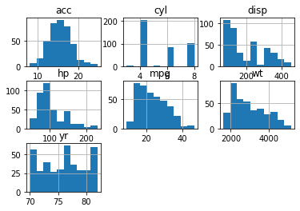

```python
data_df.hist()
```

We see,

1) acceleration column is normally distributed

2) mpg and weight columns are positively skewed

3) Horse power, cylinders, year and displacement are multimodal

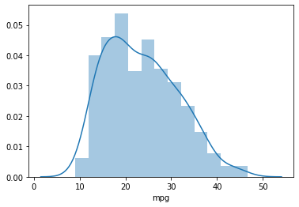

```python
sns.distplot(data_df['mpg'])
```

```python
print("Skewness of mpg: %f" % data_df['mpg'].skew())
print("Kurtosis of mpg: %f" % data_df['mpg'].kurt())
```

```
Skewness of mpg: 0.457066
Kurtosis of mpg: -0.510781
```

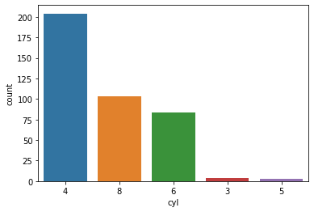

```python
sns.countplot(x='cyl',data=data_df, order=data_df['cyl'].value_counts().index)
```

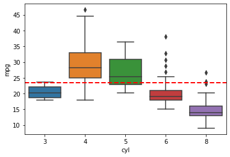

```python
var = 'model year'
fig = sns.boxplot(x='cyl', y='mpg', data=data_df)
plt.axhline(data_df.mpg.mean(),color='r',linestyle='dashed',linewidth=2)
```

```python
data_df['cyl'].value_counts(normalize=True)
```

```
4    0.512563
8    0.258794
6    0.211055
3    0.010050
5    0.007538
Name: cyl, dtype: float64
```

51% of the cars have 4 cylinders, 25% with 8 cylinders and 21% have 6 cylinders. Very less number of cars have cylinders 3 and 5 respectively

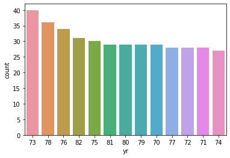

```python
sns.countplot(x='yr',data=data_df, order=data_df['yr'].value_counts().index)
```

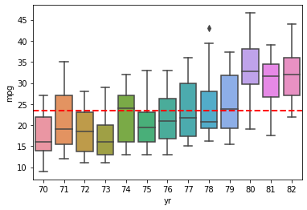

```python
var = 'model year'
fig = sns.boxplot(x='yr', y='mpg', data=data_df)
plt.axhline(data_df.mpg.mean(),color='r',linestyle='dashed',linewidth=2)
```

Cars are more or less evenly picked w.r.t to the model year

```python
print(data_df.corr())
```

```
           cyl      disp        hp        wt       acc        yr       mpg
cyl   1.000000  0.950721  0.839313  0.896017 -0.505419 -0.348746 -0.775396
disp  0.950721  1.000000  0.893996  0.932824 -0.543684 -0.370164 -0.804203
hp    0.839313  0.893996  1.000000  0.860886 -0.684620 -0.411959 -0.771762
wt    0.896017  0.932824  0.860886  1.000000 -0.417457 -0.306564 -0.831741
acc  -0.505419 -0.543684 -0.684620 -0.417457  1.000000  0.288137  0.420289
yr   -0.348746 -0.370164 -0.411959 -0.306564  0.288137  1.000000  0.579267
mpg  -0.775396 -0.804203 -0.771762 -0.831741  0.420289  0.579267  1.000000
```

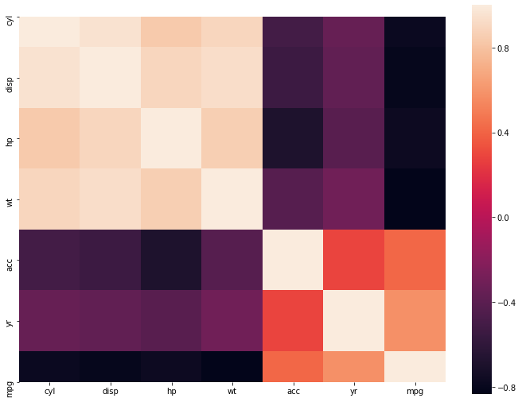

```python
f, ax = plt.subplots(figsize=(12, 9))
sns.heatmap(data_df.corr(),square=True)
```

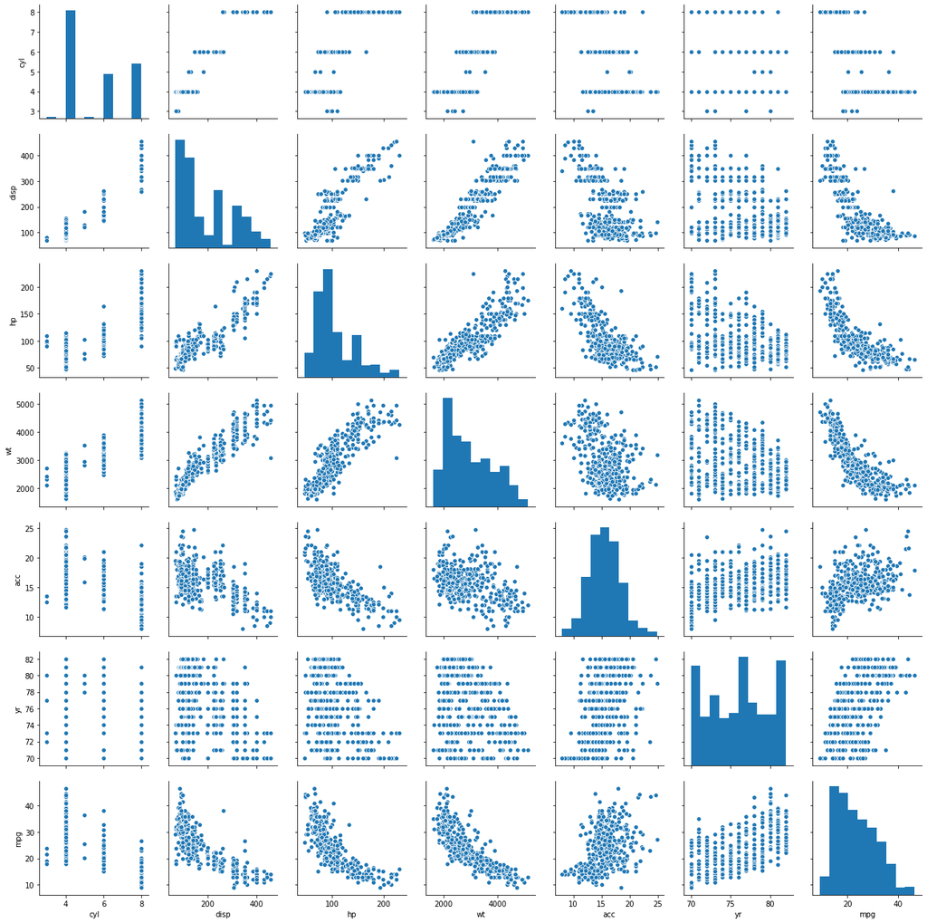

```python
sns.pairplot(data_df)
```

Inferences:

- acceleration column is normally distributed
- mpg and weight columns are positively skewed
- Horse power, cylinders, year and displacement are multimodal
- Cylinders, displacement, horsepower and weight are highly correlated with each other and all these columns have a strong negative correlation with mpg
- Acceleration and model year have some positive correlation towards mpg column

```python
numeric_cols=data_df.select_dtypes(include=[np.number]).columns
```

```python
from scipy.stats import zscore
data_df[numeric_cols].apply(zscore)
```

|  | cyl | disp | hp | wt | acc | yr | mpg |
| --- | --- | --- | --- | --- | --- | --- | --- |
| 0 | 1.498191 | 1.090604 | 0.669769 | 0.630870 | -1.295498 | -1.627426 | -0.706439 |
| 1 | 1.498191 | 1.503514 | 1.587162 | 0.854333 | -1.477038 | -1.627426 | -1.090751 |
| 2 | 1.498191 | 1.196232 | 1.193994 | 0.550470 | -1.658577 | -1.627426 | -0.706439 |
| 3 | 1.498191 | 1.061796 | 1.193994 | 0.546923 | -1.295498 | -1.627426 | -0.962647 |
| 4 | 1.498191 | 1.042591 | 0.931882 | 0.565841 | -1.840117 | -1.627426 | -0.834543 |
| ... | ... | ... | ... | ... | ... | ... | ... |
| 393 | -0.856321 | -0.513026 | -0.483525 | -0.213324 | 0.011586 | 1.621983 | 0.446497 |
| 394 | -0.856321 | -0.925936 | -1.374706 | -0.993671 | 3.279296 | 1.621983 | 2.624265 |
| 395 | -0.856321 | -0.561039 | -0.535947 | -0.798585 | -1.440730 | 1.621983 | 1.087017 |
| 396 | -0.856321 | -0.705077 | -0.667003 | -0.408411 | 1.100822 | 1.621983 | 0.574601 |
| 397 | -0.856321 | -0.714680 | -0.588370 | -0.296088 | 1.391285 | 1.621983 | 0.958913 |

398 rows × 7 columns

### K means clustering

```python
cols=['mpg','car name']
X =  data_df.drop(cols,axis=1,inplace=False)
```

```python
X.shape
```

```
(398, 6)
```

```python
WCSS=[]
```

```python
for i in range(1,11):
    kmeans = KMeans(n_clusters=i,init='k-means++',max_iter=300,n_init=10,random_state=0)
    kmeans.fit(X)
    WCSS.append(kmeans.inertia_)
```

Elbow Method

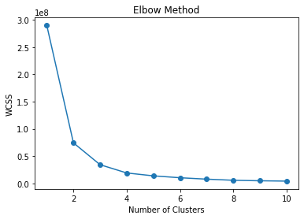

```python
plt.plot(range(1,11),WCSS,marker="o")
plt.title('Elbow Method')
plt.xlabel('Number of Clusters')
plt.ylabel('WCSS')
plt.show()
```

Optimal value of K means to be 4, as beyond 4 the reduction in the wcss is not so significant

To find the centroid at k=4

```python
kmeans = KMeans(n_clusters=4)
kmeans = kmeans.fit(X)
labels = kmeans.predict(X)
centroids = kmeans.cluster_centers_
print("Centroid values:")
print(centroids)
```

```
Centroid values:
[[6.63218391e+00 2.58126437e+02 1.15701149e+02 3.49324138e+03
  1.57310345e+01 7.56781609e+01]
 [3.97872340e+00 9.82588652e+01 7.38439716e+01 2.11143972e+03
  1.65914894e+01 7.66170213e+01]
 [4.76237624e+00 1.59118812e+02 9.60198020e+01 2.76543564e+03
  1.57247525e+01 7.70891089e+01]
 [8.00000000e+00 3.56536232e+02 1.65130435e+02 4.36659420e+03
  1.30420290e+01 7.36086957e+01]]
```

```python
print(labels)
```

```
[0 0 0 0 0 3 3 3 3 0 0 0 0 2 1 2 2 2 1 1 2 1 1 1 2 3 3 3 3 1 1 1 1 2 0 0 0
 0 3 3 3 3 3 3 3 2 1 0 0 1 1 1 1 1 1 1 1 1 1 1 1 1 3 3 3 3 0 3 3 3 3 1 0 3
 3 3 2 2 2 1 1 1 2 1 1 3 0 3 3 0 3 3 3 3 3 3 0 2 0 2 2 2 1 3 3 3 3 2 1 1 1
 1 1 2 1 3 3 1 1 2 2 0 2 2 0 2 2 2 0 1 2 1 2 0 0 0 3 3 3 3 3 1 1 1 1 1 1 1
 1 2 1 1 0 0 0 0 3 3 3 3 0 0 0 0 2 0 0 1 2 2 2 2 1 2 2 1 0 2 2 2 2 1 2 1 2
 1 1 3 3 3 3 0 0 2 2 1 1 1 1 0 0 0 0 1 1 1 2 0 3 0 2 0 3 3 0 0 1 1 1 1 1 0
 3 3 3 0 0 0 0 3 3 3 3 1 2 1 2 1 1 1 1 2 2 2 1 1 1 1 1 0 0 0 0 0 2 2 0 0 0
 2 0 0 0 0 0 3 1 2 1 1 2 2 2 1 2 0 2 0 1 1 0 2 2 0 0 0 0 3 0 3 3 0 3 1 1 1
 2 0 0 0 0 1 1 1 1 2 2 2 2 1 1 1 1 2 2 2 0 1 2 2 1 1 1 2 1 1 1 2 0 1 1 1 1
 2 1 2 2 1 2 2 2 2 1 1 1 1 1 1 1 1 1 1 1 1 1 1 1 2 2 0 0 2 2 0 0 2 0 2 2 1
 2 2 2 2 2 1 1 1 1 1 1 1 1 1 1 1 2 2 2 2 2 1 2 2 1 1 2 2]
```

```python
data_df['k4_labels']=labels
```

```python
data_df.k4_labels.value_counts().sort_index()
```

```
0     87
1    141
2    101
3     69
Name: k4_labels, dtype: int64
```

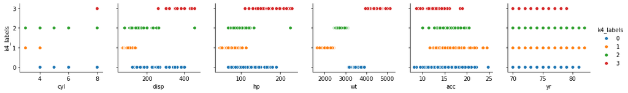

```python
sns.pairplot(data_df,hue='k4_labels',y_vars=['k4_labels'],x_vars=['cyl','disp','hp','wt','acc','yr'])
```

```python
print(data_df.corr()['k4_labels'])
```

```
cyl          0.261946
disp         0.320486
hp           0.426731
wt           0.372046
acc         -0.313393
yr          -0.130373
mpg         -0.253182
k4_labels    1.000000
Name: k4_labels, dtype: float64
```

#### Hierarchical Clustering

```python
from scipy.cluster.hierarchy import dendrogram,linkage
```

```python
z_cols=['cyl','disp','hp','wt','acc','yr']
Z=linkage(data_df[z_cols],method='ward',metric='euclidean')
```

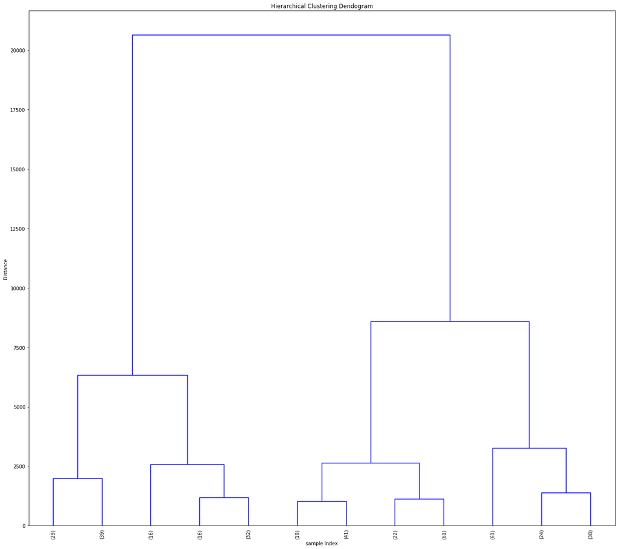

```python
plt.figure(figsize=(18, 16))
plt.title('Hierarchical Clustering Dendogram')
plt.xlabel('sample index')
plt.ylabel('Distance')
dendrogram(Z,leaf_rotation=90.0,p=12,color_threshold=12,leaf_font_size=10,truncate_mode='lastp')
plt.tight_layout()
```

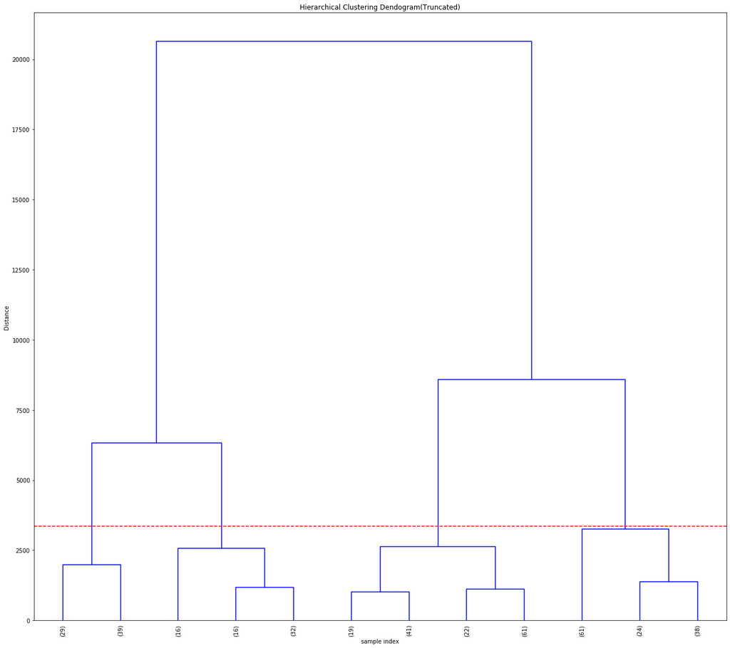

```python
plt.figure(figsize=(18, 16))
plt.title('Hierarchical Clustering Dendogram(Truncated)')
plt.xlabel('sample index')
plt.ylabel('Distance')
dendrogram(Z,leaf_rotation=90.0,p=12,color_threshold=12,leaf_font_size=10,truncate_mode='lastp')
plt.axhline(y=3350,color='r',linestyle='--')
plt.tight_layout()
```

To form 4 clusters, optimal distance will be in the range 3300 to 6000. Choosing any value between 3300 and 6000 we will see the 4 clusters are clearly differntiated

```python
max_d=3350
```

```python
from scipy.cluster.hierarchy import fcluster
```

```python
z_clusters=fcluster(Z,max_d,criterion='distance')
```

```python
z_clusters
```

```
array([1, 1, 1, 1, 1, 2, 2, 2, 2, 1, 1, 1, 1, 4, 3, 4, 4, 4, 3, 3, 4, 3,
       3, 3, 4, 2, 2, 2, 2, 3, 3, 3, 3, 4, 1, 1, 4, 4, 2, 2, 2, 2, 2, 2,
       2, 4, 3, 4, 4, 3, 3, 3, 3, 3, 3, 3, 3, 3, 3, 3, 3, 3, 2, 2, 2, 2,
       1, 2, 2, 2, 2, 3, 1, 2, 2, 2, 4, 4, 4, 3, 3, 3, 4, 3, 3, 2, 1, 1,
       2, 1, 2, 2, 2, 2, 2, 2, 1, 4, 4, 4, 4, 4, 3, 2, 2, 2, 2, 4, 3, 3,
       3, 3, 3, 4, 3, 2, 2, 3, 3, 4, 4, 1, 4, 4, 1, 4, 4, 4, 1, 3, 3, 3,
       4, 1, 1, 1, 2, 2, 2, 2, 2, 3, 3, 3, 3, 3, 3, 3, 3, 4, 3, 3, 4, 1,
       1, 4, 2, 2, 2, 2, 1, 1, 1, 1, 4, 4, 4, 3, 4, 4, 4, 4, 3, 4, 4, 3,
       4, 4, 4, 4, 4, 3, 3, 3, 4, 3, 3, 2, 2, 1, 2, 4, 1, 4, 4, 3, 3, 3,
       3, 1, 1, 1, 4, 3, 3, 3, 4, 4, 1, 4, 4, 1, 2, 2, 1, 1, 3, 3, 3, 3,
       3, 1, 2, 2, 2, 1, 1, 1, 1, 2, 2, 2, 2, 3, 4, 3, 4, 3, 3, 3, 3, 4,
       4, 4, 3, 3, 3, 3, 3, 1, 1, 1, 1, 4, 4, 4, 1, 4, 1, 4, 1, 1, 1, 1,
       4, 2, 3, 4, 3, 3, 4, 4, 4, 3, 4, 4, 4, 1, 3, 3, 4, 4, 4, 4, 1, 1,
       1, 1, 1, 2, 2, 1, 1, 3, 3, 3, 4, 1, 1, 4, 1, 3, 3, 3, 3, 4, 4, 4,
       4, 3, 3, 3, 3, 4, 4, 4, 1, 3, 4, 4, 3, 3, 3, 4, 3, 3, 3, 4, 4, 3,
       3, 3, 3, 4, 3, 4, 4, 3, 4, 4, 4, 4, 3, 3, 3, 3, 3, 3, 3, 3, 3, 3,
       3, 3, 3, 3, 3, 4, 4, 4, 4, 4, 4, 1, 1, 4, 1, 4, 4, 3, 4, 4, 4, 4,
       4, 3, 3, 3, 3, 3, 3, 3, 3, 3, 3, 3, 4, 4, 4, 4, 4, 3, 4, 4, 3, 3,
       4, 4], dtype=int32)
```

```python
data_df['z_labels']=z_clusters
```

```python
data_df.z_labels.value_counts().sort_index()
```

```
1     68
2     64
3    143
4    123
Name: z_labels, dtype: int64
```

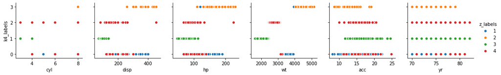

```python
sns.pairplot(data_df,hue='z_labels',y_vars=['k4_labels'],x_vars=['cyl','disp','hp','wt','acc','yr'])
```

```python
print(data_df.corr()['z_labels'])
```

```
cyl         -0.606216
disp        -0.569988
hp          -0.482526
wt          -0.546044
acc          0.237184
yr           0.218842
mpg          0.433876
k4_labels    0.194082
z_labels     1.000000
Name: z_labels, dtype: float64
```

```python
#### Lets verify the cluster profiling for K Means and Hirerchical and compare both
```

```python
cluster_profiling_k4=data_df.groupby('k4_labels').mean()
cluster_profiling_k4['frequency']=data_df.k4_labels.value_counts().sort_index()
cluster_profiling_k4
```

| k4_labels | cyl | disp | hp | wt | acc | yr | mpg | z_labels | frequency |
| --- | --- | --- | --- | --- | --- | --- | --- | --- | --- |
| 0 | 6.632184 | 258.126437 | 115.701149 | 3493.241379 | 15.731034 | 75.678161 | 18.406897 | 1.827586 | 87 |
| 1 | 3.978723 | 98.258865 | 73.843972 | 2111.439716 | 16.591489 | 76.617021 | 30.791489 | 3.000000 | 141 |
| 2 | 4.762376 | 159.118812 | 96.019802 | 2765.435644 | 15.724752 | 77.089109 | 24.261386 | 3.980198 | 101 |
| 3 | 8.000000 | 356.536232 | 165.130435 | 4366.594203 | 13.042029 | 73.608696 | 13.991304 | 1.927536 | 69 |

```python
cluster_profiling_z=data_df.groupby('z_labels').mean()
cluster_profiling_z['frequency']=data_df.z_labels.value_counts().sort_index()
cluster_profiling_z
```

| z_labels | cyl | disp | hp | wt | acc | yr | mpg | k4_labels | frequency |
| --- | --- | --- | --- | --- | --- | --- | --- | --- | --- |
| 1 | 7.014706 | 278.985294 | 124.470588 | 3624.838235 | 15.105882 | 75.588235 | 17.510294 | 0.220588 | 68 |
| 2 | 8.000000 | 358.093750 | 167.046875 | 4398.593750 | 13.025000 | 73.375000 | 13.889062 | 3.000000 | 64 |
| 3 | 3.979021 | 98.486014 | 73.972028 | 2116.279720 | 16.583217 | 76.594406 | 30.738462 | 1.013986 | 143 |
| 4 | 4.983740 | 170.821138 | 96.235772 | 2858.552846 | 15.966667 | 76.934959 | 23.443902 | 1.609756 | 123 |

### Model Comparision

Comparing the cluster profiling for K means and Hirerchical we see that the clusters formed by both the methods are slightly similiar for 2 cluster but for the other two the centers got shifted a little(the cluster which has mpg value average as 18.40 and 24.2 for kmeans, having corresponding ones in Hirerchical which has the mpg value as 17.51 and 23.44

We see there are optimal number of clusters is 4

#### Linear Regression on different clusters

```python
X0=data_df[data_df.k4_labels==0][z_cols]
```

```python
y0=data_df[data_df.k4_labels==0]['mpg']
```

```python
X0.shape
```

```
(87, 6)
```

```python
y0.shape
```

```
(87,)
```

```python
from sklearn.model_selection import train_test_split
```

```python
# Split X and y into training and test set in 80:20 ratio

X0_train, X0_test, y0_train, y0_test = train_test_split(X0, y0, test_size=0.20, random_state=1)
```

```python
from sklearn.linear_model import LinearRegression
regression_model0 = LinearRegression()
regression_model0.fit(X0_train, y0_train)
```

```
LinearRegression(copy_X=True, fit_intercept=True, n_jobs=None, normalize=False)
```

```python
print(regression_model0.coef_)
```

```
[ 0.19284194 -0.00112446 -0.04211316 -0.00326809 -0.08891195  0.60943143]
```

```python
X1=data_df[data_df.k4_labels==1][z_cols]
```

```python
y1=data_df[data_df.k4_labels==1]['mpg']
```

```python
X1.shape
```

```
(141, 6)
```

```python
y1.shape
```

```
(141,)
```

```python
X1_train, X1_test, y1_train, y1_test = train_test_split(X1, y1, test_size=0.20, random_state=1)
```

```python
regression_model1 = LinearRegression()
regression_model1.fit(X1_train, y1_train)
```

```
LinearRegression(copy_X=True, fit_intercept=True, n_jobs=None, normalize=False)
```

```python
print(regression_model1.coef_)
```

```
[ 9.56524151e+00 -8.00028772e-02  5.52077072e-03 -5.08757230e-03
  3.06943051e-01  1.03127899e+00]
```

```python
X2=data_df[data_df.k4_labels==2][z_cols]
```

```python
y2=data_df[data_df.k4_labels==2]['mpg']
```

```python
X2.shape
```

```
(101, 6)
```

```python
y2.shape
```

```
(101,)
```

```python
X2_train, X2_test, y2_train, y2_test = train_test_split(X2, y2, test_size=0.20, random_state=1)
```

```python
regression_model2 = LinearRegression()
regression_model2.fit(X2_train, y2_train)
```

```
LinearRegression(copy_X=True, fit_intercept=True, n_jobs=None, normalize=False)
```

```python
print(regression_model2.coef_)
```

```
[ 0.38563063 -0.01365213 -0.0189625  -0.0078954  -0.01529205  0.65150315]
```

```python
X3=data_df[data_df.k4_labels==3][z_cols]
```

```python
y3=data_df[data_df.k4_labels==3]['mpg']
```

```python
X2.shape
```

```
(101, 6)
```

```python
y2.shape
```

```
(101,)
```

```python
X3_train, X3_test, y3_train, y3_test = train_test_split(X3, y3, test_size=0.20, random_state=1)
```

```python
regression_model3 = LinearRegression()
regression_model3.fit(X3_train, y3_train)
```

```
LinearRegression(copy_X=True, fit_intercept=True, n_jobs=None, normalize=False)
```

```python
print(regression_model3.coef_)
```

```
[ 0.          0.00104426 -0.0180409  -0.00159973 -0.40231024  0.44883891]
```

```python
X_full=data_df[z_cols]
```

```python
y_full=data_df['mpg']
```

```python
X.shape
```

```
(398, 6)
```

```python
y.shape
```

[output not shown]

```python
X_full_train, X_full_test, y_full_train, y_full_test = train_test_split(X_full, y_full, test_size=0.20, random_state=1)
```

```python
regression_model_full = LinearRegression()
regression_model_full.fit(X_full_train, y_full_train)
```

```
LinearRegression(copy_X=True, fit_intercept=True, n_jobs=None, normalize=False)
```

```python
print(regression_model_full.coef_)
```

```
[-0.08206433  0.00547967 -0.00322006 -0.00690642  0.08031121  0.79926322]
```

```python
print("Regression model score while considering separate model for individual clusters:")
print("1, ",regression_model0.score(X0_test, y0_test))
print("2, ",regression_model1.score(X1_test, y1_test))
print("3, ",regression_model2.score(X2_test, y2_test))
print("4, ",regression_model3.score(X3_test, y3_test))
print("Regression model score for model build on the entire dataset: ", regression_model_full.score(X_full_test, y_full_test))
```

```
Regression model score while considering separate model for individual clusters:
1,  0.2012797103370585
2,  0.5295797342362667
3,  0.3279751661855901
4,  0.23058328161164252
Regression model score for model build on the entire dataset:  0.843478443506076
```

#### We observe that the building models for individual clusters is not fruitful in this case. Considering the entire unclustered data for model building helping in getting the maximum possible accuracy for Linear Regression which is 84.3%